# Perspectives on Computational Modeling: PS#5

Xingyun Wu

02/12/2017

## Problem 1: Describe the data (1 point)

The histogram of the variable `biden` is shown as below.

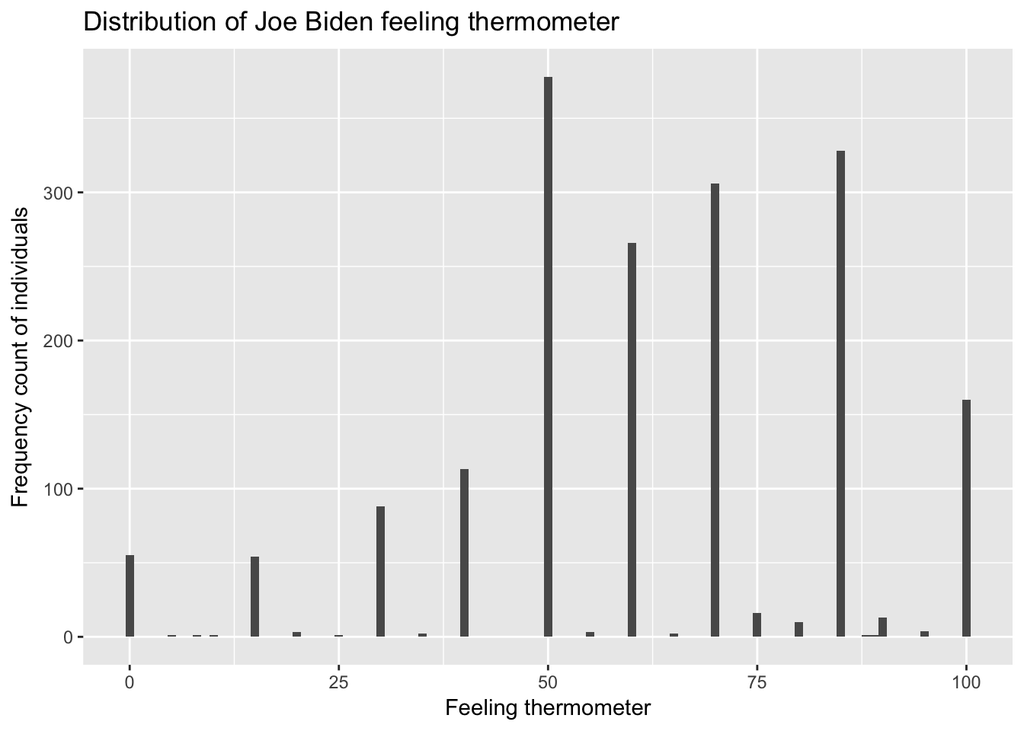

```r
ggplot(mydata, mapping = aes(x = biden)) +
  geom_histogram(binwidth=1) +
  labs(title = "Distribution of Joe Biden feeling thermometer",
       x = "Feeling thermometer",
       y = "Frequency count of individuals")
```

## Problem 2: Simple linear regression (2 points)

Statistics of the linear regression are shown as below.

```r
problem2 <- lm(biden ~ age, data = mydata)
summary(problem2)
```

```
##
## Call:
## lm(formula = biden ~ age, data = mydata)
##
## Residuals:
##     Min      1Q  Median      3Q     Max
## -64.876 -12.318  -1.257  21.684  39.617
##
## Coefficients:
##             Estimate Std. Error t value Pr(>|t|)
## (Intercept) 59.19736    1.64792   35.92   <2e-16 ***
## age          0.06241    0.03267    1.91   0.0563 .
## ---
## Signif. codes:  0 '***' 0.001 '**' 0.01 '*' 0.05 '.' 0.1 ' ' 1
##
## Residual standard error: 23.44 on 1805 degrees of freedom
## Multiple R-squared:  0.002018,   Adjusted R-squared:  0.001465
## F-statistic: 3.649 on 1 and 1805 DF,  p-value: 0.05626
```

1. These is a relationship between the predictor `age` and the response `biden`(feeling thermometer). One unit of increase in `age` could on average produce 0.06241 unit of increase in `biden`. But the relationship is not statistically significant, given the P-value of `age`. There is only a 90% chance to reject the hull hypothesis that `age` is irrelevant to `biden`.
2. The relationship is very weak, not statistically significant enough. The P-value for `age` is 0.05626, which has not reached the 95% conficence interval.
3. Positive, since the estimated parameter of `age` is 0.06241, positive in this regression model.
4. $R^2$ = 0.002018, which means 0.2018% of variance in `biden` is explained by `age`. This is a bad model, because the predictor could not explain the variance of resonse well.

```
##   age .fitted   .se.fit     ymin     ymax
## 1  45 62.0056 0.5577123 60.91248 63.09872
```

5. The predicted `biden` with an age of 45 is 62.0056. The associated 95% confidence intervals are (60.91248, 63.09872). There is approximately a 95% chance that `age` has the presented influence on `biden`.
6. The plot is shown as below.

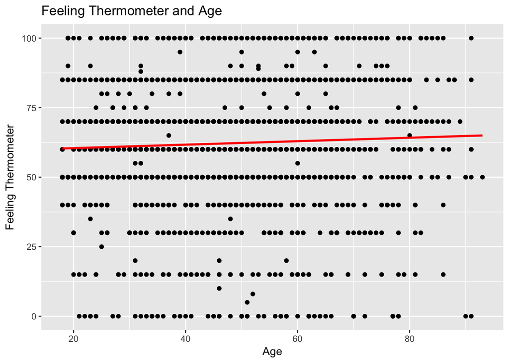

```r
grid <- mydata %>%
  data_grid(age)
grid <- grid %>%
  add_predictions(problem2)
ggplot(mydata, aes(x = age)) +
  geom_point(aes(y = biden)) +
  geom_line(aes(y = pred), data = grid, color = "red", size = 1)+
  labs(x = 'Age',
       y = 'Feeling Thermometer',
       title= 'Feeling Thermometer and Age')
```

## Problem 3: Multiple linear regression (2 points)

```r
problem3 <- lm(biden ~ age + female + educ, data = mydata)
summary(problem3)
```

```
##
## Call:
## lm(formula = biden ~ age + female + educ, data = mydata)
##
## Residuals:
##     Min      1Q  Median      3Q     Max
## -67.084 -14.662   0.703  18.847  45.105
##
## Coefficients:
##             Estimate Std. Error t value Pr(>|t|)
## (Intercept) 68.62101    3.59600  19.083  < 2e-16 ***
## age          0.04188    0.03249   1.289    0.198
## female       6.19607    1.09670   5.650 1.86e-08 ***
## educ        -0.88871    0.22469  -3.955 7.94e-05 ***
## ---
## Signif. codes:  0 '***' 0.001 '**' 0.01 '*' 0.05 '.' 0.1 ' ' 1
##
## Residual standard error: 23.16 on 1803 degrees of freedom
## Multiple R-squared:  0.02723,    Adjusted R-squared:  0.02561
## F-statistic: 16.82 on 3 and 1803 DF,  p-value: 8.876e-11
```

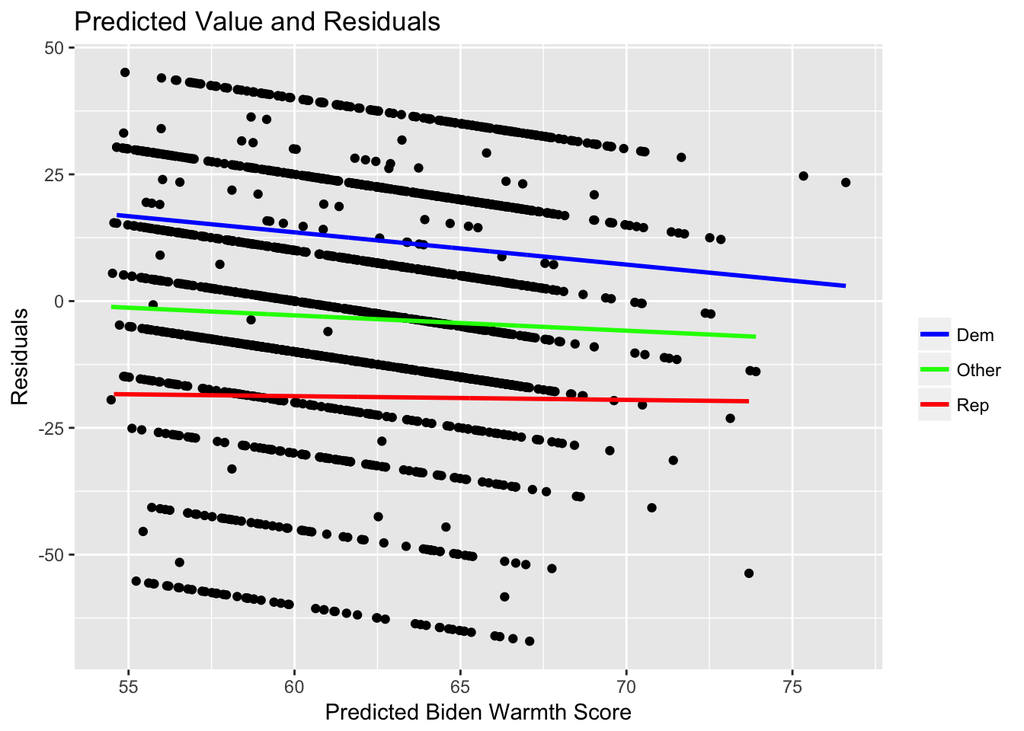

## Problem 4: Multiple linear regression model (with even more variables!) (3 points)

```r
problem4 <- lm(biden ~ age + female + educ + dem + rep, data=mydata)
summary(problem4)
```

```
##
## Call:
## lm(formula = biden ~ age + female + educ + dem + rep, data = mydata)
##
## Residuals:
##     Min      1Q  Median      3Q     Max
## -75.546 -11.295   1.018  12.776  53.977
##
## Coefficients:
##              Estimate Std. Error t value Pr(>|t|)
## (Intercept)  58.81126    3.12444  18.823  < 2e-16 ***
## age           0.04826    0.02825   1.708   0.0877 .
## female        4.10323    0.94823   4.327 1.59e-05 ***
## educ         -0.34533    0.19478  -1.773   0.0764 .
## dem          15.42426    1.06803  14.442  < 2e-16 ***
## rep         -15.84951    1.31136 -12.086  < 2e-16 ***
## ---
## Signif. codes:  0 '***' 0.001 '**' 0.01 '*' 0.05 '.' 0.1 ' ' 1
##
## Residual standard error: 19.91 on 1801 degrees of freedom
## Multiple R-squared:  0.2815, Adjusted R-squared:  0.2795
## F-statistic: 141.1 on 5 and 1801 DF,  p-value: < 2.2e-16
```

1. Yes, its parameter changes from 6.19607 to 4.10323. This means its magnitude has decreased, although its influence on `biden` remains positive and its significant level remains the same.
2. $R^2$ = 0.2795, since we need to look at adjusted $R^2$ for multiple linear regression. About 27.95% of variation in `biden` is explained by the predictors. This is a better model than the age + gender + education model, since the $R^2$ has greatly increased.
3. The plot is shown as below. The problem found in the plot of previous model has been partly solved. Now all every group has residuals distributed around 0.

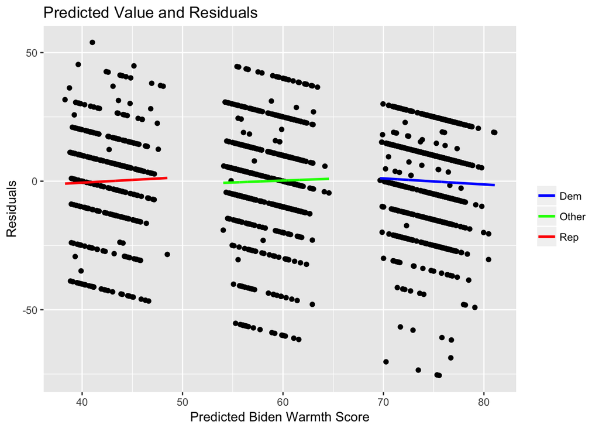

## Problem 5: Interactive linear regression model (2 points)

```r
data_filter <- mydata[(mydata$dem == 1)|(mydata$rep == 1), ]
problem5 <- lm(biden ~ female * dem, data_filter)
summary(problem5)
```

```
##
## Call:
## lm(formula = biden ~ female * dem, data = data_filter)
##
## Residuals:
##     Min      1Q  Median      3Q     Max
## -75.519 -13.070   4.223  11.930  55.618
##
## Coefficients:
##             Estimate Std. Error t value Pr(>|t|)
## (Intercept)   39.382      1.455  27.060  < 2e-16 ***
## female         6.395      2.018   3.169  0.00157 **
## dem           33.688      1.835  18.360  < 2e-16 ***
## female:dem    -3.946      2.472  -1.597  0.11065
## ---
## Signif. codes:  0 '***' 0.001 '**' 0.01 '*' 0.05 '.' 0.1 ' ' 1
##
## Residual standard error: 19.42 on 1147 degrees of freedom
## Multiple R-squared:  0.3756, Adjusted R-squared:  0.374
## F-statistic:   230 on 3 and 1147 DF,  p-value: < 2.2e-16
```

```
##   female dem  .fitted   .se.fit     ymin     ymax
## 1      1   1 75.51883 0.8881114 73.77813 77.25953
## 2      1   0 45.77720 1.3976638 43.03778 48.51662
## 3      0   1 73.06954 1.1173209 70.87959 75.25949
## 4      0   0 39.38202 1.4553632 36.52951 42.23453
```

1. For female Democrats: predicted feeling thermometer is 75.51883, with 95% confidence intervals (73.77813, 77.25953).
2. For female Republicans: predicted feeling thermometer is 45.77720, with 95% confidence intervals (43.03778, 48.51662).
3. For male Democrats: predicted feeling thermometer is 73.06954, with 95% confidence intervals (70.87959, 75.25949).
4. For male Republicans: predicted feeling thermometer is 39.38202 with 95% confidence intervals (36.52951, 42.23453).
5. Yes, the relationship between party ID and `biden` differ by gender, although the interaction term is not statistically significant. Looking at the estimated parameter for the interaction term, for males, the Democrats report on average 33.688 more feeling thermometers than the Republicans. But for females, the difference between Democrats and Republicans shrinkes to about 29.742.
6. Yes, the relationship between gender and `biden` differ by party ID, although the interaction term is not statistically significant. Looking at the estimated parameter for the interaction term, for Republicans, female report on average 6.395 more feeling thermometer. But for Democrats, the difference between females and males shrinks to about 2.449.